# STAT/MATH 495: Problem Set 01

Jonathan Che

September 07, 2017

## Setting up

```r
library(tidyverse)
train <- read_csv("https://rudeboybert.github.io/STAT495/static/Titanic/train.csv")
test <- read_csv("https://rudeboybert.github.io/STAT495/static/Titanic/test.csv")
submission <- read_csv("https://rudeboybert.github.io/STAT495/static/Titanic/gender_submission.csv")
```

## Exploratory data analysis

In class, we found that just predicting only women to survive resulted in about 75% accuracy. We’ll explore the training data to see if there are any simple heuristics we can use to improve this prediction.

```r
with(train, table(Sex, Survived))
```

```
##         Survived
## Sex        0   1
##   female  81 233
##   male   468 109
```

We notice that as expected, females are much more likely to survive. Still, though, nearly 20% of males in the training set survived. We want to see if there are any simple heuristics we can use to try to predict some of these male survivors.

The famous adage from the Titanic sinking is: “Women and children first!”. Let’s see if male children are more likely to survive than older males.

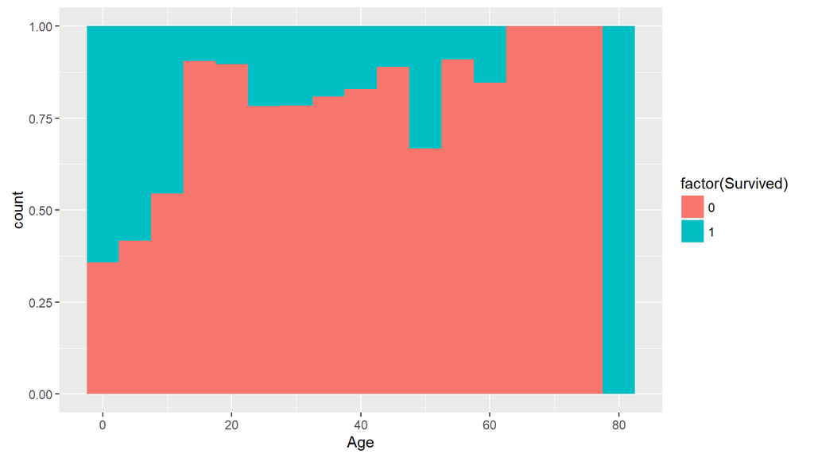

```r
males <- filter(train, Sex=="male")
ggplot(males, aes(x=Age, fill=factor(Survived))) +
  geom_histogram(binwidth=5, position="fill")
```

We’ll make the qualitative judgment of calling anyone less than 13 years old a “child”. It seems like boys have a much higher survival rate than other men.

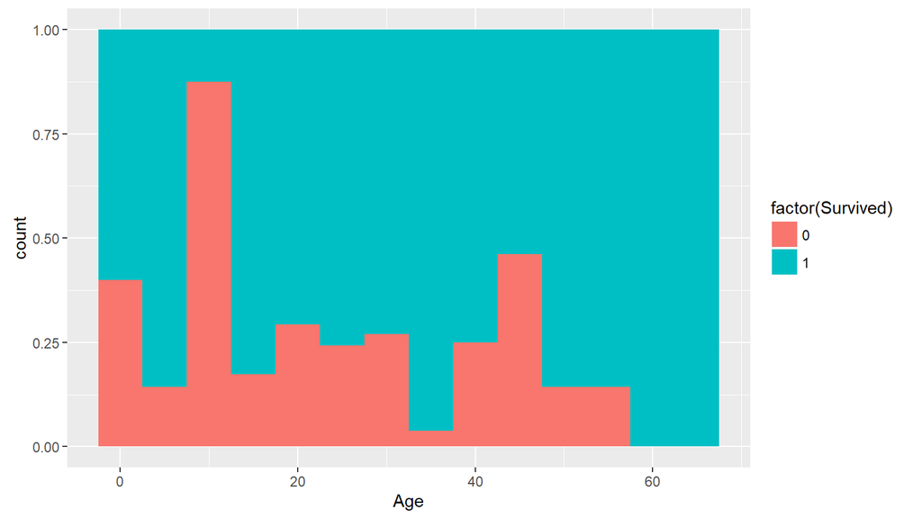

```r
females <- filter(train, Sex=="female")
ggplot(females, aes(x=Age, fill=factor(Survived))) +
  geom_histogram(binwidth=5, position="fill")
```

Just for fun, we check whether females have this bias too. In general, it doesn’t seem that girls have a significantly better chance of survival than other women!

## Making predictions

Based on our EDA, I build a model that has women and boys (males less than 13 years old) surviving. I would expect such a change to be very marginally better than the model that only uses passenger sex, since there were not many children on the Titanic overall, and only slightly more than 50% of the boys in the training set survived.

```r
preds <- test %>%
  mutate(is_young = Age < 13,
         Survived = (Sex == "female") | (Sex == "male" & is_young)) %>%
  mutate(Survived = as.integer(Survived)) %>%
  select(PassengerId, Survived)
# Some Age values are NA, resulting in NA predictions
# We classify males with missing age as "old" males because
# males are generally less likely to survive.
preds[is.na(preds)] <- 0

# writing output to submission csv file
write_csv(preds, "submission.csv")
```